# Assignment 4

Begin with a mosaic matrix that looks at the relationship between the dichotomous variables. This reinforces what was seen in the frequency counts - that accuracy seems to be related to longer exposure. Additionally, it looks like participants were more accurate when perpetrators were absent and less accurate when perpetrators were present in the lineup. These trends are reinforced by the bar graphs of accuracy against exposure and perpetrator presence or absence.

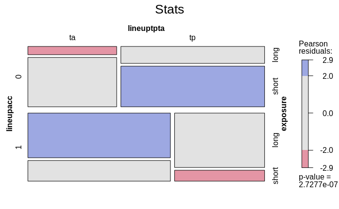

```r
mosaic(~ lineupacc + lineuptpta + exposure, data = traindata, main = "Stats", shade = T, legend = T)
```

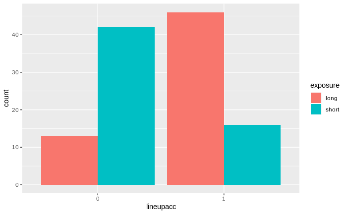

```r
ggplot(traindata) +
  geom_bar(mapping = aes(x = lineupacc, fill = exposure), position = "dodge")
```

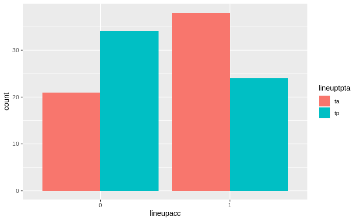

```r
ggplot(traindata) +
  geom_bar(mapping = aes(x = lineupacc, fill = lineuptpta), position = "dodge")
```

Next, look at the relationship between accuracy and the dependent variables, using boxplots. It looks like confidence may be related to accuracy, but the other variables are not. This is in keeping with what the correlation matrices showed.

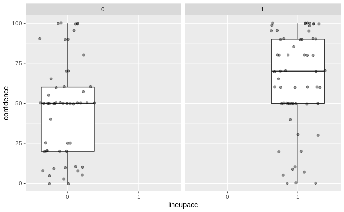

```r
ggplot(traindata, aes(lineupacc, confidence)) +
  geom_boxplot() +
  geom_jitter(alpha = .4) +
  facet_grid(~lineupacc)
```

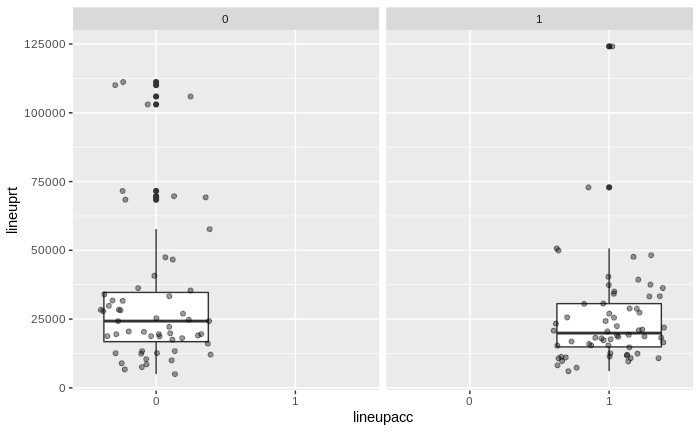

```r
ggplot(traindata, aes(lineupacc, lineuprt)) +
  geom_boxplot() +
  geom_jitter(alpha = .4) +
  facet_grid(~lineupacc)
```

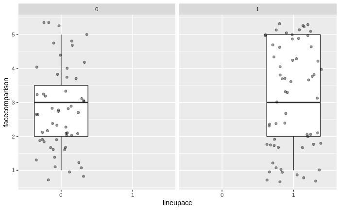

```r
ggplot(traindata, aes(lineupacc, facecomparison)) +
  geom_boxplot() +
  geom_jitter(alpha = .4) +
  facet_grid(~lineupacc)
```

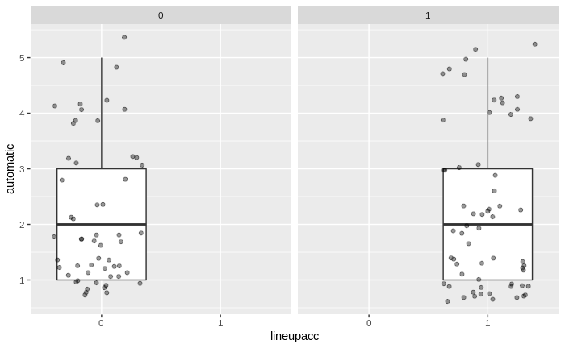

```r
ggplot(traindata, aes(lineupacc, automatic)) +
  geom_boxplot() +
  geom_jitter(alpha = .4) +
  facet_grid(~lineupacc)
```

Based on the examination above, the data can be fit to models using exposure, perpetrator absence or presence, and confidence.

Question 4